# STSCI 4630 - Lec 04

Harry Lu

January 31, 2019

**White Noise Processes**

Prediction: the best linear prediction of $X_{t+k}$, given $X_1,\cdots,X_t$ is the estimate of $\mu$ and $\bar{X}$

- $\text{E}(X_t)=\mu$ for all $t$
- $\text{Var}(X_t)=\sigma^2$ for all $t$
- $\text{Cov}(X_t,X_u)=0$ for $t\neq u$

Consider $a_1X_1+\cdots+a_tX_t=\widehat{X_{t+k}}$

Choose $a_1,\cdots,a_t$ to minimize $\text{E}\left[\left(X_{t+k}-\widehat{X_{t+k}}\right)^2\right]$, then we get $\widehat{X_{t+k}}=\bar{X}$

**Estimation of the auto-covariance function**

$$\widehat{\gamma(k)}=\frac{1}{n-k}\sum_{t=1}^{n-k}\left(X_t-\bar{X}\right)\left(X_{t+k}-\bar{X}\right)$$

When $k=0$

$$\widehat{\gamma(0)}=\widehat{\sigma^2}=\frac{1}{n}\sum_{t=1}^{n}\left(X_t-\bar{X}\right)^2$$

$$\widehat{\rho(k)}=\frac{\widehat{\gamma(k)}}{\widehat{\gamma(0)}}=\text{estimates the ACF}$$

*ACF: Auto-Correlation Function

**Weekly Stationary Process**

- $\text{E}(X_t)=\mu$ for all $t$
- $\text{Var}(X_t)=\sigma^2$ for all $t$
- $\text{Cov}(X_t,X_u)=\gamma(|t-u|)$

Given $\{X_1,X_2,X_3,X_4,\cdots,X_{t-2},X_{t-1},X_t\}$

$\widehat{\gamma(1)}$ :

- $\{X_2,\cdots,X_t\}$
- $\{X_1,\cdots,X_{t-1}\}$

$\widehat{\gamma(2)}$ :

- $\{X_3,\cdots,X_t\}$
- $\{X_1,\cdots,X_{t-2}\}$

**Plot the sample ACF**

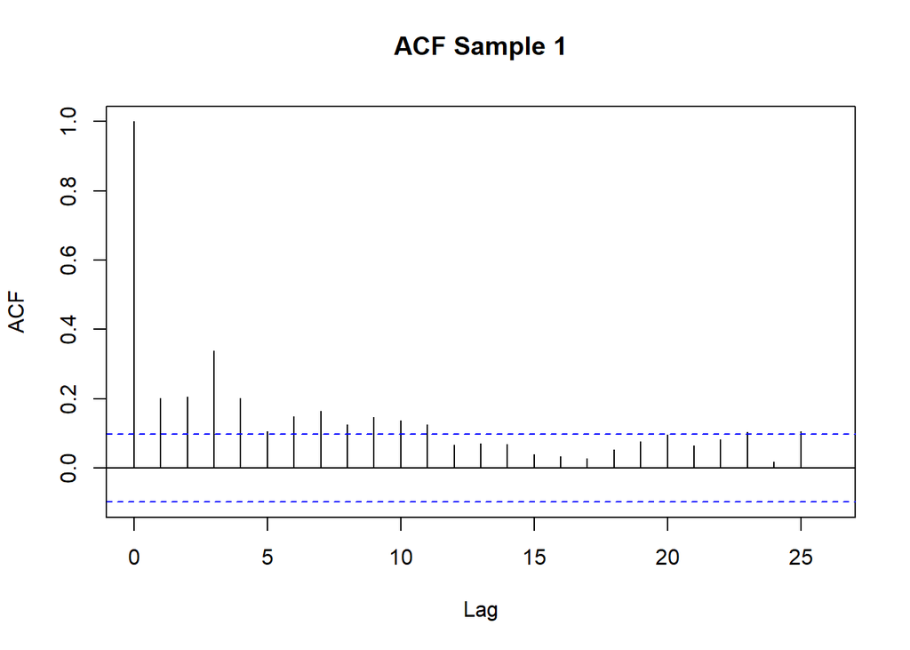

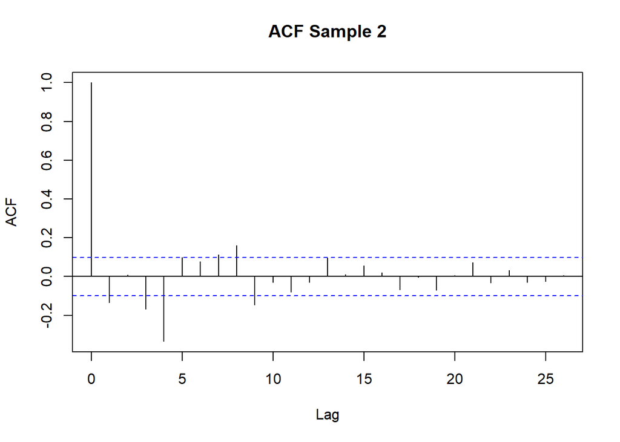

**Ljung-Box Test**

$H_0:\rho(1)=\cdots=\rho(k)=0$

$H_A:\text{not all }\rho(1),\cdots,\rho(k)\text{ are }0$

**Time Series Models**

- Autoregressive Processes: AR(p)
- Moving Average Processes: MA(q)

**AR(1) Process**

Suppose $\epsilon_1,\epsilon_2,\cdots$ is a weak white noise process with mean $0$ and variance $\sigma_\epsilon^2$

The process $X_1,X_2,\cdots$ is an AR(1) process if for constants $\mu$ and $\phi$ we have

$$X_t-\mu=\phi(X_{t-1}-\mu)+\epsilon_t$$

i.e. $X_t=(1-\phi)\mu+\phi X_{t-1}+\epsilon_t$

So $\text{E}(X_t)=(1-\phi)\mu+\phi\text{E}(X_{t-1})$

and $\text{Var}(X_t)=\phi^2\text{Var}(X_{t-1})+\sigma_\epsilon^2$

$\{X_t\}$ is stationary provided $|\phi|<1$

Note: $\text{Cov}(X_{t-1},\epsilon_t)=0$

$$\begin{align}
X_t
&=
(1-\phi)\mu+\phi X_{t-1}+\epsilon_t\\
&=
(1-\phi)\mu+\phi[(1-\phi)\mu+\phi X_{t-2}+\epsilon_{t-1}]+\epsilon_t\\
&=
\underbrace{(1-\phi)\mu+\phi(1-\phi)\mu}_{(1-\phi)\mu[1+\phi+\phi^2+\cdots]}+\underbrace{\phi^2X_{t-2}}_{\phi^t X_0}+\underbrace{\phi\epsilon_{t-1}+\epsilon_t}_{\epsilon_t+\phi\epsilon_{t-1}+\cdots}\\
&=
\cdots\\
&=\mu+\sum_{h=0}^{\infty}\phi^h\epsilon_{t-h}
\end{align}$$

$$\begin{align}
\text{E}(X_t)&=\mu\\
\text{Var}(X_t)
&=
\sigma_\epsilon^2+\phi^2\sigma_\epsilon^2+\phi^4\sigma_\epsilon^2+\cdots\\
&=
\sigma_\epsilon^2(1+\phi^2+\phi^4+\cdots)\\
&=
\frac{\sigma_\epsilon^2}{1-\phi^2}\\
&=
\gamma(0)\\
\text{Cov}(X_t,X_{t+h})
&=
\gamma(h)\\
&=
\frac{\sigma_\epsilon^2}{1-\phi^2}\cdot\phi^{|h|}\\
\rho(X_t,X_{t+h})
&=
\rho(h)\\
&=
\frac{\gamma(h)}{\gamma(0)}\\
&=
\phi^{|h|}
\end{align}$$

$\phi>0$

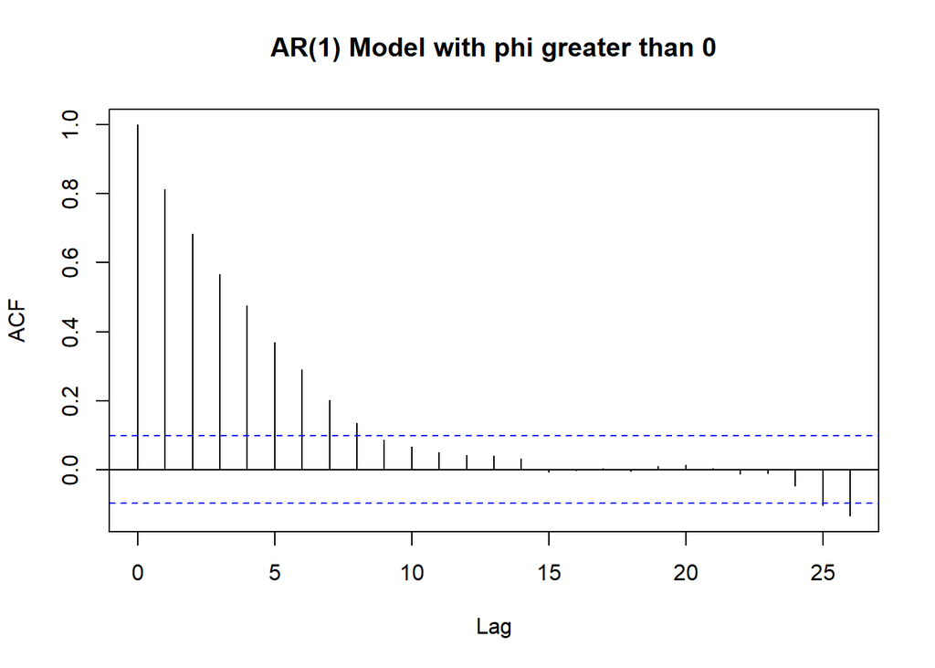

$\phi<0$

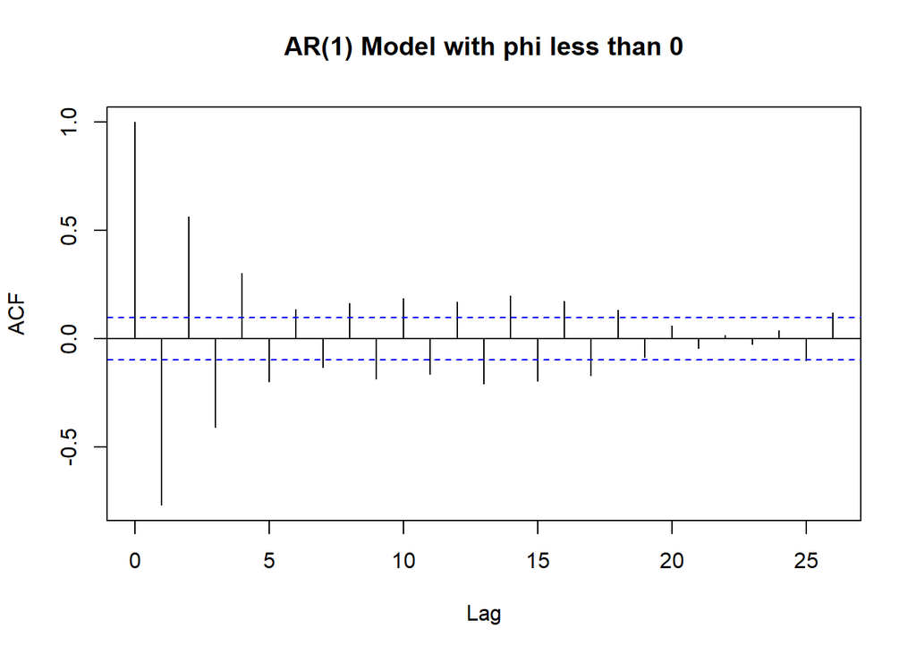

Fit the model using MLE and obtain estimates $\hat\mu$ and $\hat\phi$, this yields residuals $\widehat{\epsilon_t}=(X_t-\hat\mu)-\hat\phi(X_{t-1}-\hat\mu)$

The $\widehat{\epsilon_t}$ should have the ACF of a white noise process

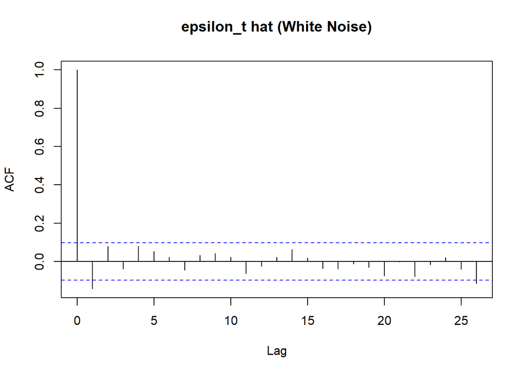

**AR(p) Model**

$$X_t-\mu=\phi_1(X_{t-1}-\mu)+\phi_2(X_{t-2}-\mu)+\cdots+\phi_p(X_{t-p}-\mu)+\epsilon_t$$

**MA(1) Process**

Suppose $\epsilon_1,\epsilon_2,\cdots$ is a weak white noise process with mean $0$ and variance $\sigma_\epsilon^2$

$$X_t-\mu=\epsilon_t+\theta\epsilon_{t-1}$$

$$X_t=\mu+\epsilon_t+\theta\epsilon_{t-1}$$

- $\text{E}(X_t)=\mu$
- $\text{Var}(X_t)=\sigma_\epsilon^2(1+\theta^2)=\gamma(0)$

$\gamma(1)=\theta\sigma_\epsilon^2$

$\gamma(h)=0$ for $|h|>1$

$\rho(1)=\frac{\theta}{1+\theta^2}=\frac{\gamma(1)}{\gamma(0)}$

$\rho(h)=\frac{\gamma(h)}{\gamma(0)}$ for $|h|>1$

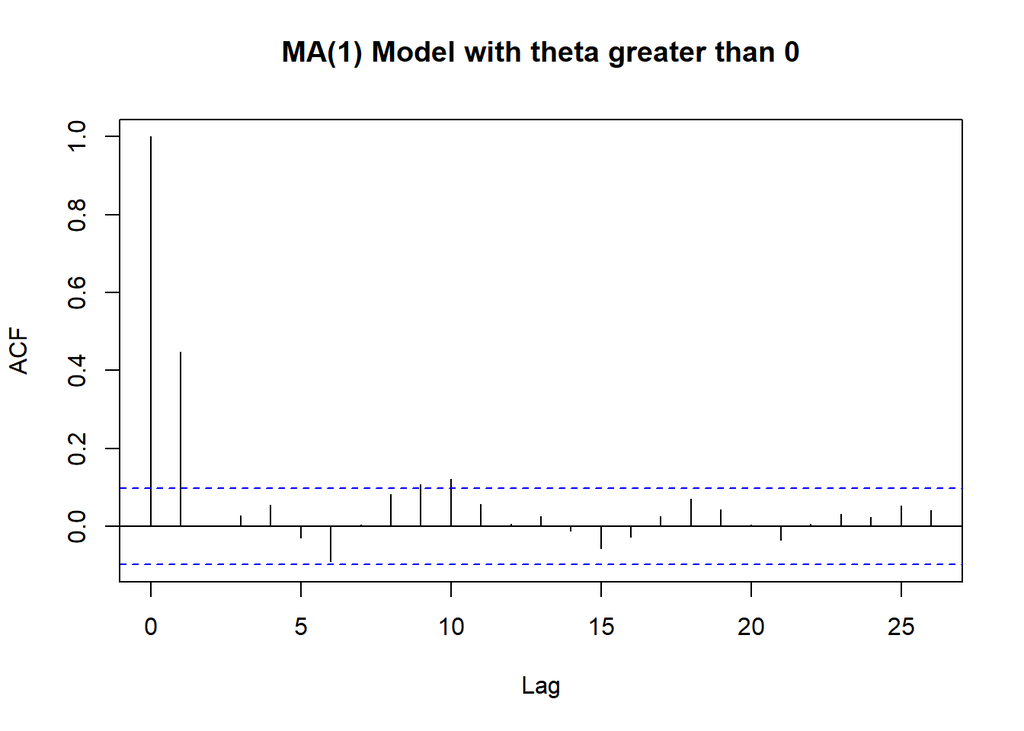

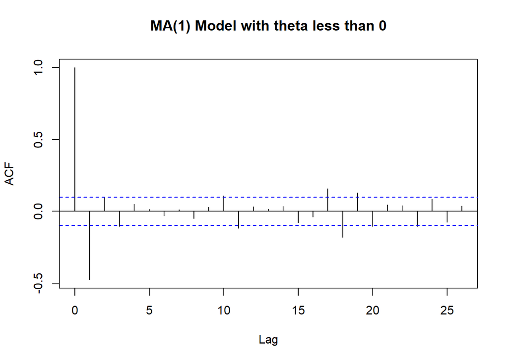

**MA(q) Model**

$$X_t-\mu=\epsilon_t+\theta_1\epsilon_{t-1}+\cdots+\theta_q\epsilon_{t-q}$$

$\gamma(h)=0$ for $|h|>q$

**ARMA(p,q) model**

$$\begin{align}
X_t-\mu
&=
\phi_1(X_{t-1}-\mu)+\phi_2(X_{t-2}-\mu)+\cdots+\phi_p(X_{t-p}-\mu)\\
&\quad+
\epsilon_t+\theta_1\epsilon_{t-1}+\cdots+\theta_q\epsilon_{t-q}
\end{align}$$

**Model Comparison**

AIC: $-\text{max likelihood}+2p$, where $p$ is the number of fitted parameters

BIC: $-\text{max likelihood}+\log(n)\cdot p$, where $p$ is the number of fitted parameters and $n$ is the sample size

In general BIC is more commonly used

Thanks to *Zhenjie Shen* for help with the notes.